# Prediction of preschool education enrollment in Central Asian countries

Data Report

**GitHub link**: https://github.com/sophiyaberdiyeva/preschool_enrollment_in_central_asia

# 1. Data exploration

### 1.1. Loading the preprocessed individual data

Pre-processing included the following steps *(in the back end)*:

1. Opening SPSS (.sav) files for children under 5, households and household members questionnaires.
2. Removing all variables that are irrelevant for the analysis.
3. Filtering out children outside the range of 3-4 years old.
4. Adding unique indexes to each of the dataframes.
5. (Left) joining dataframes to retrieve all necessary variables from each questionnaire.
6. Removal of duplicating variables after joins.

```r
kazakhstan_mics <- get_and_preprocess_mics_data("Kazakhstan")
kyrgyzstan_mics <- get_and_preprocess_mics_data("Kyrgyzstan")
turkmenistan_mics <- get_and_preprocess_mics_data("Turkmenistan")
uzbekistan_mics <- get_and_preprocess_mics_data("Uzbekistan")

tajikistan_dhs <- preprocess_dhs_data(child_set_path = "data/raw/Tajikistan/TJKR81SV_childrens_recode/TJKR81FL.sav",
                                  house_members_path = "data/raw/Tajikistan/TJPR81SV_household_member_recode/TJPR81FL.sav")
```

### 1.2. Loading region-level data

```r
region_kz <- read_csv("../data/raw/regional_data_Kazakhstan_2024.csv")
region_kg <- read_csv("../data/raw/regional_data_Kyrgyzstan_2023.csv")
region_tm <- read_csv("../data/raw/regional_data_Turkmenistan_2024.csv")
region_uz <- read_csv("../data/raw/regional_data_Uzbekistan_2022.csv")
region_tj <- read_csv("../data/raw/regional_data_Tajikistan_2023.csv")
```

After loading all of the data, we explored the main variable statistics across datasets. Below an exhaustive list of dataset description tables is provided (for each country and level of analysis).

## Kazakhstan

### Individual level

Data frame: kazakhstan_mics

| ID | Name | Label | missings | Values | Value Labels | Freq. | % |
| --- | --- | --- | --- | --- | --- | --- | --- |
| 1 | LN | Line number | 0 (0.00%) | *range: 2-13* |  |  |  |
| 2 | UF1 | Cluster number | 0 (0.00%) | *range: 2-1659* |  |  |  |
| 3 | UF2 | Household number | 0 (0.00%) | *range: 1-24* |  |  |  |
| 4 | UF3 | Child’s line number | 0 (0.00%) | *range: 2-13* |  |  |  |
| 5 | UF4 | Mother / Caretaker’s line number | 0 (0.00%) | *range: 1-11* |  |  |  |
| 6 | UF10 | Consent | 0 (0.00%) | 1 2 | YES NO / NOT ASKED | 2880 0 | 100.00 0.00 |
| 7 | UF17 | Result of interview for children under 5 | 0 (0.00%) | 1 2 3 4 5 6 96 | COMPLETED NOT AT HOME REFUSED PARTLY COMPLETED INCAPACITATED NO ADULT CONSENT FOR MOTHER / CAREGIVER AGE 15-17 OTHER | 2880 0 0 0 0 0 0 | 100.00 0.00 0.00 0.00 0.00 0.00 0.00 |
| 8 | UB2 | Age of child | 0 (0.00%) | 0 1 2 3 4 | 0 1 2 3 4 | 0 0 0 1550 1330 | 0.00 0.00 0.00 53.82 46.18 |
| 9 | ED5A | Highest level of education attended | 3 (0.10%) | 0 1 2 3 4 5 6 7 8 9 | PRESCHOOL PRIMARY [1-4] LOWER SECONDARY [5-9] UPPER SECONDARY [10-11/12] TVE POST-SECONDARY UNDERGRADUATE POSTGRADUATE DK NO RESPONSE | 5 2 95 418 606 365 1342 44 0 0 | 0.17 0.07 3.30 14.53 21.06 12.69 46.65 1.53 0.00 0.00 |
| 10 | EC1 | Number of children’s books or picture books for child | 0 (0.00%) | 0 1 2 3 4 5 6 7 8 9 10 99 | NONE ONE TWO THREE FOUR FIVE SIX SEVEN EIGHT NINE TEN OR MORE BOOKS NO RESPONSE | 911 174 411 327 204 250 112 42 36 18 392 3 | 31.63 6.04 14.27 11.35 7.08 8.68 3.89 1.46 1.25 0.63 13.61 0.10 |
| 11 | EC2A | Play with homemade toys | 0 (0.00%) | 1 2 8 9 | YES NO DK NO RESPONSE | 1547 1330 2 1 | 53.72 46.18 0.07 0.03 |
| 12 | EC2B | Play with toys from shops | 0 (0.00%) | 1 2 8 9 | YES NO DK NO RESPONSE | 2840 38 0 2 | 98.61 1.32 0.00 0.07 |
| 13 | EC2C | Play with household objects or outside objects | 0 (0.00%) | 1 2 8 9 | YES NO DK NO RESPONSE | 2143 732 2 3 | 74.41 25.42 0.07 0.10 |
| 14 | EC3A | Number of days left alone for more than one hour | 0 (0.00%) | 0 1 2 3 4 5 6 7 8 9 | NONE ONE TWO THREE FOUR FIVE SIX SEVEN DK NO RESPONSE | 2775 50 33 12 3 3 0 3 1 0 | 96.35 1.74 1.15 0.42 0.10 0.10 0.00 0.10 0.03 0.00 |
| 15 | EC3B | Number of days left in the care of another child less than 10 years old for more than one hour | 0 (0.00%) | 0 1 2 3 4 5 6 7 8 9 | NONE ONE TWO THREE FOUR FIVE SIX SEVEN DK NO RESPONSE | 2656 125 60 23 5 3 1 6 1 0 | 92.22 4.34 2.08 0.80 0.17 0.10 0.03 0.21 0.03 0.00 |
| 16 | UCD2A | Took away privileges | 0 (0.00%) | 1 2 9 | YES NO NO RESPONSE | 1035 1844 1 | 35.94 64.03 0.03 |
| 17 | UCD2B | Explained why behaviour was wrong | 0 (0.00%) | 1 2 9 | YES NO NO RESPONSE | 2240 639 1 | 77.78 22.19 0.03 |
| 18 | UCD2D | Shouted, yelled or screamed at child | 0 (0.00%) | 1 2 9 | YES NO NO RESPONSE | 884 1994 2 | 30.69 69.24 0.07 |
| 19 | UCD2E | Gave child something else to do | 0 (0.00%) | 1 2 9 | YES NO NO RESPONSE | 1076 1802 2 | 37.36 62.57 0.07 |
| 20 | UCD2H | Called child dumb, lazy or another name | 0 (0.00%) | 1 2 9 | YES NO NO RESPONSE | 62 2816 2 | 2.15 97.78 0.07 |
| 21 | EC5A | In past 3 days, read books or looks at picture book | 0 (0.00%) | 1 2 8 9 | YES NO DK NO RESPONSE | 2041 838 1 0 | 70.87 29.10 0.03 0.00 |
| 22 | EC5B | In past 3 days, tell stories | 0 (0.00%) | 1 2 8 9 | YES NO DK NO RESPONSE | 2065 813 2 0 | 71.70 28.23 0.07 0.00 |
| 23 | EC5C | In past 3 days, sang songs | 0 (0.00%) | 1 2 8 9 | YES NO DK NO RESPONSE | 1932 946 2 0 | 67.08 32.85 0.07 0.00 |
| 24 | EC5D | In past 3 days, took outside | 0 (0.00%) | 1 2 8 9 | YES NO DK NO RESPONSE | 2552 327 1 0 | 88.61 11.35 0.03 0.00 |
| 25 | EC5E | In past 3 days, played with | 0 (0.00%) | 1 2 8 9 | YES NO DK NO RESPONSE | 2635 242 3 0 | 91.49 8.40 0.10 0.00 |
| 26 | EC5F | In past 3 days, spent time naming, counting, or drawing | 0 (0.00%) | 1 2 8 9 | YES NO DK NO RESPONSE | 2163 714 2 1 | 75.10 24.79 0.07 0.03 |
| 27 | EC6 | Child walks on an uneven surface without falling | 0 (0.00%) | 1 2 8 9 | YES NO DK NO RESPONSE | 2751 127 2 0 | 95.52 4.41 0.07 0.00 |
| 28 | EC7 | Child jumps up with both feet leaving the ground | 0 (0.00%) | 1 2 8 9 | YES NO DK NO RESPONSE | 2674 198 8 0 | 92.85 6.88 0.28 0.00 |
| 29 | EC8 | Child dresses himself/herself without help | 0 (0.00%) | 1 2 8 9 | YES NO DK NO RESPONSE | 2430 449 1 0 | 84.38 15.59 0.03 0.00 |
| 30 | EC9 | Child fasten and unfasten buttons without help | 0 (0.00%) | 1 2 8 9 | YES NO DK NO RESPONSE | 1623 1237 20 0 | 56.35 42.95 0.69 0.00 |
| 31 | EC10 | Child says 10 or more words | 0 (0.00%) | 1 2 8 9 | YES NO DK NO RESPONSE | 2706 172 1 1 | 93.96 5.97 0.03 0.03 |
| 32 | EC11 | Child speaks using sentences of 3 or more words that go together | 0 (0.00%) | 1 2 8 9 | YES NO DK NO RESPONSE | 2483 394 1 2 | 86.22 13.68 0.03 0.07 |
| 33 | EC12 | Child speaks using sentences of 5 or more words that go together | 397 (13.78%) | 1 2 8 9 | YES NO DK NO RESPONSE | 2054 425 4 0 | 82.72 17.12 0.16 0.00 |
| 34 | EC13 | Child correctly uses any of the words ‘I’, ‘you’, ‘she’, or ‘he’ | 0 (0.00%) | 1 2 8 9 | YES NO DK NO RESPONSE | 2501 375 3 1 | 86.84 13.02 0.10 0.03 |
| 35 | EC14 | Child consistently names an object when shown | 0 (0.00%) | 1 2 8 9 | YES NO DK NO RESPONSE | 2618 253 9 0 | 90.90 8.78 0.31 0.00 |
| 36 | EC15 | Child recognizes at least 5 letters of the alphabet | 0 (0.00%) | 1 2 8 9 | YES NO DK NO RESPONSE | 1170 1692 17 1 | 40.62 58.75 0.59 0.03 |
| 37 | EC16 | Child writes own name | 0 (0.00%) | 1 2 8 9 | YES NO DK NO RESPONSE | 213 2660 7 0 | 7.40 92.36 0.24 0.00 |
| 38 | EC17 | Child recognized all numbers from 1 to 5 | 0 (0.00%) | 1 2 8 9 | YES NO DK NO RESPONSE | 1945 922 13 0 | 67.53 32.01 0.45 0.00 |
| 39 | EC18 | Child gives correct amount of objects when asked | 0 (0.00%) | 1 2 8 9 | YES NO DK NO RESPONSE | 1856 958 65 1 | 64.44 33.26 2.26 0.03 |
| 40 | EC19 | Child counts 10 objects without mistakes | 0 (0.00%) | 1 2 8 9 | YES NO DK NO RESPONSE | 1086 1769 23 2 | 37.71 61.42 0.80 0.07 |
| 41 | EC20 | Child does an activity without repeatedly asking for help or giving up too quickly | 0 (0.00%) | 1 2 8 9 | YES NO DK NO RESPONSE | 2099 760 19 2 | 72.88 26.39 0.66 0.07 |
| 42 | EC21 | Child asks about familiar people other than parents when they are not there | 0 (0.00%) | 1 2 8 9 | YES NO DK NO RESPONSE | 2638 240 1 1 | 91.60 8.33 0.03 0.03 |
| 43 | EC22 | Child offers to help someone who seems to need help | 0 (0.00%) | 1 2 8 9 | YES NO DK NO RESPONSE | 2082 748 48 2 | 72.29 25.97 1.67 0.07 |
| 44 | EC23 | Child gets along well with other children | 0 (0.00%) | 1 2 8 9 | YES NO DK NO RESPONSE | 2801 67 10 2 | 97.26 2.33 0.35 0.07 |
| 45 | EC24 | How often child seems to be very sad or depressed | 0 (0.00%) | 1 2 3 4 5 8 9 | DAILY WEEKLY MONTHLY A FEW TIMES A YEAR NEVER DK NO RESPONSE | 125 100 111 436 2051 52 5 | 4.34 3.47 3.85 15.14 71.22 1.81 0.17 |
| 46 | EC25 | How much child kicks, bites, or hits other children or adults | 0 (0.00%) | 1 2 3 4 5 8 9 | NOT AT ALL LESS THE SAME MORE A LOT MORE DK NO RESPONSE | 2151 636 35 37 1 17 3 | 74.69 22.08 1.22 1.28 0.03 0.59 0.10 |
| 47 | UB8 | Currently attending early childhood education programme | 879 (30.52%) | 1 2 9 | YES NO NO RESPONSE | 1967 33 1 | 98.30 1.65 0.05 |
| 48 | line_num_index |  | 0 (0.00%) |  | <output omitted> | <output omitted> | <output omitted> |
| 49 | house_index |  | 0 (0.00%) |  | <output omitted> | <output omitted> | <output omitted> |
| 50 | HH48 | Number of HH members | 0 (0.00%) | *range: 2-13* |  |  |  |
| 51 | HH51 | Number of children under age 5 | 0 (0.00%) | *range: 1-6* |  |  |  |
| 52 | HC10C | Any member of household own: Motorcycle, scooter or electric scooter (moped) | 0 (0.00%) | 1 2 9 | YES NO NO RESPONSE | 294 2586 0 | 10.21 89.79 0.00 |
| 53 | HC10E | Any member of household own: Car, truck or van | 0 (0.00%) | 1 2 9 | YES NO NO RESPONSE | 2056 824 0 | 71.39 28.61 0.00 |
| 54 | HH1 | Cluster number | 0 (0.00%) | *range: 2-1659* |  |  |  |
| 55 | HH2 | Household number | 0 (0.00%) | *range: 1-24* |  |  |  |
| 56 | HH7 | Region | 0 (0.00%) | 10 11 15 19 23 27 31 33 35 39 43 47 55 59 61 <…> | ABAY AKMOLA AKTOBE ALMATY ATYRAU WEST KAZAKHSTAN ZHAMBYL ZHETYSU KARAGANDA KOSTANAY KYZYLORDA MANGYSTAU PAVLODAR NORTH KAZAKHSTAN TURKISTAN <… truncated> | 137 94 191 145 182 109 234 164 76 100 218 114 117 96 205 | 4.76 3.26 6.63 5.03 6.32 3.78 8.13 5.69 2.64 3.47 7.57 3.96 4.06 3.33 7.12 |
| 57 | HL1 | Line number | 0 (0.00%) | *range: 2-13* |  |  |  |
| 58 | HH6 | Area | 0 (0.00%) | 1 2 | URBAN RURAL | 1502 1378 | 52.15 47.85 |
| 59 | HL13 | Does natural mother live in HH | 7 (0.24%) | 1 2 9 | YES NO NO RESPONSE | 2850 23 0 | 99.20 0.80 0.00 |
| 60 | HL17 | Does natural father live in HH | 32 (1.11%) | 1 2 9 | YES NO NO RESPONSE | 2664 184 0 | 93.54 6.46 0.00 |
| 61 | windex5 | Wealth index quintile | 0 (0.00%) | 1 2 3 4 5 | Poorest Second Middle Fourth Richest | 604 496 539 636 605 | 20.97 17.22 18.72 22.08 21.01 |
| 62 | ED4 | Ever attended school or any Early Childhood Education programme | 0 (0.00%) | 1 2 9 | YES NO NO RESPONSE | 2117 762 1 | 73.51 26.46 0.03 |

```r
# Age of child vs current enrollment (1 - Yes, 2 - No, 9 - No response)
table(kazakhstan_mics$UB8, kazakhstan_mics$UB2)
```

```
#>
#>       3   4
#>   1 993 974
#>   2  22  11
#>   9   1   0
```

**Findings**:

- Data are mostly clean, but the majority of variables for analysis need recoding from 4 answer options to binary scheme (Yes/No). We plan to merge “No”, “Don’t know” and “No Response” options together.
- Missing values are present for five variables, including the outcome. We propose the following strategies for handling this issue:
  - *EC12. Child speaks using sentences of 5 or more words that go together*: 397 missing values imputed by “No”.
  - *UB8. Currently attending early childhood education programme*: 879 (30.52%) missing values. We will recode them to “No”, since missing values are simply the result of filtering out children that have never attended preschool (which is a separate item ED4)
  - *HL13. Does natural mother live in the household*: 7 missing values - omit rows containing them.
  - *HL17. Does natural father live in the household*: 32 missing values - omit rows containing them.
  - *ED5A. Highest level of education attended (by caregiver)*: 3 missing values - omit rows containing them.
- Data are well-balanced in terms of age (53.82% for 3 y.o. and 46.18% for 4 y.o.) and urban/rural distributions (52.15% for urban and 47.85% for rural).
- There are no data on social transfers for this country

### Regional level

For regional data, we decided to provide summary statistics instead of raw observations, even though number of regions is relatively small across all countries.

```r
psych::describe(region_kz[,-c(1,2)]) %>% kbl(digits=2) %>%
  kable_styling(bootstrap_options = c("striped", "hover", "condensed"))
```

|  | vars | n | mean | sd | median | trimmed | mad | min | max | range | skew | kurtosis | se |
| --- | --- | --- | --- | --- | --- | --- | --- | --- | --- | --- | --- | --- | --- |
| popul_total_01012024 | 1 | 20 | 1001692.10 | 509646.73 | 808982.50 | 931957.69 | 245975.20 | 221584.00 | 2228675.00 | 2007091.00 | 1.05 | 0.38 | 113960.47 |
| popul_3_yo_01012024 | 2 | 20 | 21154.70 | 13295.93 | 17890.50 | 19506.31 | 10452.33 | 4607.00 | 51109.00 | 46502.00 | 0.91 | -0.28 | 2973.06 |
| popul_4_yo_01012024 | 3 | 20 | 19918.75 | 12201.96 | 17169.00 | 18266.62 | 9229.93 | 4425.00 | 51628.00 | 47203.00 | 1.05 | 0.33 | 2728.44 |
| territory_sq_km | 4 | 20 | 136245.65 | 78041.58 | 134460.00 | 136484.81 | 54165.31 | 684.00 | 300629.00 | 299945.00 | -0.09 | -0.38 | 17450.63 |
| popul_density | 5 | 20 | 310.53 | 827.58 | 5.65 | 72.11 | 2.75 | 1.17 | 3258.30 | 3257.12 | 2.54 | 5.61 | 185.05 |
| pre_teachers_total_2024 | 6 | 20 | 5074.65 | 2590.32 | 4517.00 | 4791.31 | 1959.26 | 1017.00 | 13314.00 | 12297.00 | 1.44 | 2.66 | 579.21 |
| child_per_100_places | 7 | 20 | 83.06 | 5.15 | 84.36 | 83.73 | 3.97 | 69.00 | 89.25 | 20.25 | -1.12 | 0.70 | 1.15 |
| places_in_pre_total | 8 | 20 | 58650.15 | 38055.27 | 48121.00 | 53135.19 | 18100.32 | 10039.00 | 181807.00 | 171768.00 | 1.67 | 2.92 | 8509.42 |
| public_pre | 9 | 20 | 273.80 | 114.43 | 285.00 | 277.94 | 138.62 | 75.00 | 435.00 | 360.00 | -0.21 | -1.27 | 25.59 |
| private_pre | 10 | 20 | 310.25 | 332.30 | 163.50 | 254.25 | 154.93 | 8.00 | 1119.00 | 1111.00 | 1.18 | 0.12 | 74.30 |
| total_pre_2024 | 11 | 20 | 584.05 | 308.28 | 518.50 | 539.12 | 174.95 | 98.00 | 1432.00 | 1334.00 | 1.23 | 1.08 | 68.93 |
| public_pre_share | 12 | 20 | 57.29 | 28.93 | 66.60 | 57.96 | 33.92 | 11.92 | 95.84 | 83.92 | -0.30 | -1.49 | 6.47 |
| private_pre_share | 13 | 20 | 42.71 | 28.93 | 33.40 | 42.04 | 33.92 | 4.16 | 88.08 | 83.92 | 0.30 | -1.49 | 6.47 |
| labor_force_part_men_2024 | 14 | 20 | 73.97 | 4.60 | 74.45 | 74.18 | 2.74 | 61.20 | 83.10 | 21.90 | -0.69 | 1.17 | 1.03 |
| labor_force_part_women_2024 | 15 | 20 | 63.16 | 4.62 | 63.70 | 62.88 | 4.60 | 56.30 | 74.20 | 17.90 | 0.41 | -0.53 | 1.03 |

## Kyrgyzstan

### Individual level

Data frame: kyrgyzstan_mics

| ID | Name | Label | missings | Values | Value Labels | Freq. | % |
| --- | --- | --- | --- | --- | --- | --- | --- |
| 1 | LN | Line number | 0 (0.00%) | *range: 2-17* |  |  |  |
| 2 | UF1 | Cluster number | 0 (0.00%) | *range: 2-360* |  |  |  |
| 3 | UF2 | Household number | 0 (0.00%) | *range: 1-20* |  |  |  |
| 4 | UF3 | Child’s line number | 0 (0.00%) | *range: 2-17* |  |  |  |
| 5 | UF4 | Mother / Caretaker’s line number | 0 (0.00%) | *range: 1-11* |  |  |  |
| 6 | UF10 | Consent | 0 (0.00%) | 1 2 | YES NO / NOT ASKED | 1392 0 | 100.00 0.00 |
| 7 | UF17 | Result of interview for children under 5 | 0 (0.00%) | 1 2 3 4 5 6 96 | COMPLETED NOT AT HOME REFUSED PARTLY COMPLETED INCAPACITATED NO ADULT CONSENT FOR RESPONDENT AGE 15-17 OTHER | 1392 0 0 0 0 0 0 | 100.00 0.00 0.00 0.00 0.00 0.00 0.00 |
| 8 | UB2 | Age of child | 0 (0.00%) | *range: 3-4* |  |  |  |
| 9 | ED5A | Highest level of education attended | 1 (0.07%) | 0 1 2 3 4 5 8 9 | PRE-SCHOOL PRIMARY BASIC SECONDARY COMPLETE SECONDARY PROFESSIONAL SECONDARY/MIDDLE HIGHER DK NO RESPONSE | 1 4 117 615 274 380 0 0 | 0.07 0.29 8.41 44.21 19.70 27.32 0.00 0.00 |
| 10 | EC1 | Number of children’s books or picture books for child | 0 (0.00%) | 0 1 2 3 4 5 6 7 8 9 10 99 | NONE ONE TWO THREE FOUR FIVE SIX SEVEN EIGHT NINE TEN OR MORE BOOKS NO RESPONSE | 646 98 256 127 66 67 26 23 18 2 63 0 | 46.41 7.04 18.39 9.12 4.74 4.81 1.87 1.65 1.29 0.14 4.53 0.00 |
| 11 | EC2A | Homemade toys | 0 (0.00%) | 1 2 8 9 | YES NO DK NO RESPONSE | 777 614 1 0 | 55.82 44.11 0.07 0.00 |
| 12 | EC2B | Toys from shops | 0 (0.00%) | 1 2 8 9 | YES NO DK NO RESPONSE | 1372 20 0 0 | 98.56 1.44 0.00 0.00 |
| 13 | EC2C | Household objects or outside objects | 0 (0.00%) | 1 2 8 9 | YES NO DK NO RESPONSE | 1121 271 0 0 | 80.53 19.47 0.00 0.00 |
| 14 | EC3A | Days left alone for more than one hour | 0 (0.00%) | 0 1 2 3 4 5 6 7 8 9 | NONE ONE TWO THREE FOUR FIVE SIX SEVEN OR MORE DK NO RESPONSE | 1371 13 2 1 1 3 0 1 0 0 | 98.49 0.93 0.14 0.07 0.07 0.22 0.00 0.07 0.00 0.00 |
| 15 | EC3B | Days left in the care of another child | 0 (0.00%) | 0 1 2 3 4 5 6 7 8 9 | NONE ONE TWO THREE FOUR FIVE SIX SEVEN OR MORE DK NO RESPONSE | 1285 63 32 7 2 1 2 0 0 0 | 92.31 4.53 2.30 0.50 0.14 0.07 0.14 0.00 0.00 0.00 |
| 16 | UCD2A | Took away privileges | 0 (0.00%) | 1 2 9 | YES NO NO RESPONSE | 892 500 0 | 64.08 35.92 0.00 |
| 17 | UCD2B | Explained why behaviour was wrong | 0 (0.00%) | 1 2 9 | YES NO NO RESPONSE | 1268 123 1 | 91.09 8.84 0.07 |
| 18 | UCD2D | Shouted, yelled or screamed at child | 0 (0.00%) | 1 2 9 | YES NO NO RESPONSE | 805 587 0 | 57.83 42.17 0.00 |
| 19 | UCD2E | Gave child something else to do | 0 (0.00%) | 1 2 9 | YES NO NO RESPONSE | 372 1018 2 | 26.72 73.13 0.14 |
| 20 | UCD2H | Called child dumb, lazy or another name | 0 (0.00%) | 1 2 9 | YES NO NO RESPONSE | 262 1124 6 | 18.82 80.75 0.43 |
| 21 | EC5AA | Read books - Mother | 0 (0.00%) | ? A | <output omitted> | <output omitted> | <output omitted> |
| 22 | EC5AB | Read books - Father | 0 (0.00%) | ? B | <output omitted> | <output omitted> | <output omitted> |
| 23 | EC5AX | Read books - Other | 0 (0.00%) | ? X | <output omitted> | <output omitted> | <output omitted> |
| 24 | EC5AY | Read books - No one | 0 (0.00%) | ? Y | <output omitted> | <output omitted> | <output omitted> |
| 25 | EC5ANR | Read books - No response | 0 (0.00%) | ? | <output omitted> | <output omitted> | <output omitted> |
| 26 | EC5BA | Tell stories - Mother | 0 (0.00%) | ? A | <output omitted> | <output omitted> | <output omitted> |
| 27 | EC5BB | Tell stories - Father | 0 (0.00%) | ? B | <output omitted> | <output omitted> | <output omitted> |
| 28 | EC5BX | Tell stories - Other | 0 (0.00%) | ? X | <output omitted> | <output omitted> | <output omitted> |
| 29 | EC5BY | Tell stories - No one | 0 (0.00%) | ? Y | <output omitted> | <output omitted> | <output omitted> |
| 30 | EC5BNR | Tell stories - No response | 0 (0.00%) | ? | <output omitted> | <output omitted> | <output omitted> |

[output cut: 68 more lines]

```r
# Age of child vs attended preschool during current school year (1 - Yes, 2 - No, 9 - No response)
table(kyrgyzstan_mics$UB7, kyrgyzstan_mics$UB2)
```

```
#>
#>       3   4
#>   1 276 318
#>   2  25  13
```

- For Kyrgyzstan and Uzbekistan, number of variables is way higher (96-97 compared to 61) due to the data encoding specifics: some of the variables that had to be recoded based on sub-items and provided as separate features (“EC5[A-D]”) are missing, creating the neccessity for us to perform this recoding on our own.
- This dataset has shifted enumeration of early childhood (EC) development variables.
- Here, 6 variables have missing values (excluding social transfers-related set of items):
  - *EC27. A child speak using sentences of 5 or more words that go together*: 142 missing values will be recoded as “No”.
  - *UB7. Attended early childhood education programme of current school year*: 760 (54.60%) are missing due to filtering from ED4, will also be imputed by “No”.
  - *HL13. Does natural mother live in the household*: 3 missing values - omit rows containing them.
  - *HL17. Does natural father live in the household*: 15 missing values - omit rows containing them.
  - *ED5A. Highest level of education attended (by caregiver)*: 1 missing value - omit row containing it.
- Dataset is skewed towards rural population (67.60%).

### Regional level

```r
psych::describe(region_kg[,-c(1)]) %>% kbl(digits=2) %>%
  kable_styling(bootstrap_options = c("striped", "hover", "condensed"))
```

|  | vars | n | mean | sd | median | trimmed | mad | min | max | range | skew | kurtosis | se |
| --- | --- | --- | --- | --- | --- | --- | --- | --- | --- | --- | --- | --- | --- |
| popul_thsnd_total_01012023 | 1 | 9 | 781.96 | 463.38 | 570.9 | 781.96 | 440.93 | 273.50 | 1460.40 | 1186.90 | 0.22 | -1.87 | 154.46 |
| territory_thsnd_sq_km | 2 | 9 | 22.22 | 16.82 | 20.2 | 22.22 | 20.02 | 0.16 | 45.20 | 45.04 | 0.01 | -1.64 | 5.61 |
| popul_density | 3 | 9 | 1038.85 | 2382.38 | 38.9 | 1038.85 | 22.11 | 6.82 | 7156.25 | 7149.43 | 1.83 | 1.86 | 794.13 |
| total_pre_2023 | 4 | 9 | 212.44 | 137.60 | 178.0 | 212.44 | 90.44 | 81.00 | 505.00 | 424.00 | 0.95 | -0.43 | 45.87 |
| expen_on_pre_2023 | 5 | 9 | 360.22 | 382.05 | 246.0 | 360.22 | 117.13 | 26.00 | 1223.00 | 1197.00 | 1.27 | 0.11 | 127.35 |
| employment_rate_female_2023 | 6 | 9 | 40.61 | 11.48 | 36.3 | 40.61 | 9.93 | 28.50 | 59.90 | 31.40 | 0.51 | -1.57 | 3.83 |
| employment_rate_male_2023 | 7 | 9 | 70.58 | 7.23 | 71.8 | 70.58 | 7.26 | 60.30 | 84.20 | 23.90 | 0.36 | -0.97 | 2.41 |

## Turkmenistan

### Individual level

Data frame: turkmenistan_mics

| ID | Name | Label | missings | Values | Value Labels | Freq. | % |
| --- | --- | --- | --- | --- | --- | --- | --- |
| 1 | LN | Line number | 0 (0.00%) | *range: 2-14* |  |  |  |
| 2 | UF1 | Cluster number | 0 (0.00%) | *range: 101-750* |  |  |  |
| 3 | UF2 | Household number | 0 (0.00%) | *range: 1-20* |  |  |  |
| 4 | UF3 | Child’s line number | 0 (0.00%) | *range: 2-14* |  |  |  |
| 5 | UF4 | Mother / Caretaker’s line number | 0 (0.00%) | *range: 1-11* |  |  |  |
| 6 | UF10 | Consent | 0 (0.00%) | 1 2 | YES NO / NOT ASKED | 1398 0 | 100.00 0.00 |
| 7 | UF17 | Result of interview for children under 5 | 0 (0.00%) | 1 2 3 4 5 6 96 | COMPLETED NOT AT HOME REFUSED PARTLY COMPLETED INCAPACITATED NO ADULT CONSENT FOR MOTHER / CARETAKER AGE 15-17 OTHER | 1398 0 0 0 0 0 0 | 100.00 0.00 0.00 0.00 0.00 0.00 0.00 |
| 8 | UB2 | Age of child | 0 (0.00%) | 0 1 2 3 4 | 0 1 2 3 4 | 0 0 0 676 722 | 0.00 0.00 0.00 48.35 51.65 |
| 9 | ED5A | Highest level of education attended | 0 (0.00%) | 0 1 2 3 4 8 9 | PRE-SCHOOL/KINDERGARTEN SECONDARY(1-12) TECHNICAL VOCATIONAL SECONDARY VOCATIONAL HIGHER DK NO RESPONSE | 0 1048 132 91 127 0 0 | 0.00 74.96 9.44 6.51 9.08 0.00 0.00 |
| 10 | EC1 | Number of children’s books or picture books for child | 0 (0.00%) | 0 1 2 3 4 5 6 7 8 9 10 99 | NONE ONE TWO THREE FOUR FIVE SIX SEVEN EIGHT NINE TEN OR MORE BOOKS NO RESPONSE | 159 177 418 255 158 77 42 31 14 5 62 0 | 11.37 12.66 29.90 18.24 11.30 5.51 3.00 2.22 1.00 0.36 4.43 0.00 |
| 11 | EC2A | Play with homemade toys | 0 (0.00%) | 1 2 8 9 | YES NO DK NO RESPONSE | 1094 304 0 0 | 78.25 21.75 0.00 0.00 |
| 12 | EC2B | Play with toys from shops | 0 (0.00%) | 1 2 8 9 | YES NO DK NO RESPONSE | 1392 6 0 0 | 99.57 0.43 0.00 0.00 |
| 13 | EC2C | Play with household objects or outside objects | 0 (0.00%) | 1 2 8 9 | YES NO DK NO RESPONSE | 704 692 2 0 | 50.36 49.50 0.14 0.00 |
| 14 | EC3A | Number of days left alone for more than one hour | 0 (0.00%) | 0 1 2 3 4 5 6 7 8 9 | NONE ONE TWO THREE FOUR FIVE SIX SEVEN DK NO RESPONSE | 1373 13 7 3 2 0 0 0 0 0 | 98.21 0.93 0.50 0.21 0.14 0.00 0.00 0.00 0.00 0.00 |
| 15 | EC3B | Number of days left in the care of another child less than 10 years old for more than one hour | 0 (0.00%) | 0 1 2 3 4 5 6 7 8 9 | NONE ONE TWO THREE FOUR FIVE SIX SEVEN DK NO RESPONSE | 1371 17 7 0 2 1 0 0 0 0 | 98.07 1.22 0.50 0.00 0.14 0.07 0.00 0.00 0.00 0.00 |
| 16 | UCD2A | Took away privileges | 0 (0.00%) | 1 2 9 | YES NO NO RESPONSE | 846 552 0 | 60.52 39.48 0.00 |
| 17 | UCD2B | Explained why behaviour was wrong | 0 (0.00%) | 1 2 9 | YES NO NO RESPONSE | 1343 55 0 | 96.07 3.93 0.00 |
| 18 | UCD2D | Shouted, yelled or screamed at child | 0 (0.00%) | 1 2 9 | YES NO NO RESPONSE | 717 681 0 | 51.29 48.71 0.00 |
| 19 | UCD2E | Gave child something else to do | 0 (0.00%) | 1 2 9 | YES NO NO RESPONSE | 999 398 1 | 71.46 28.47 0.07 |
| 20 | UCD2H | Called child dumb, lazy or another name | 0 (0.00%) | 1 2 9 | YES NO NO RESPONSE | 523 875 0 | 37.41 62.59 0.00 |
| 21 | EC5A | In past 3 days, read books or looks at picture book | 0 (0.00%) | 1 2 8 9 | YES NO DK NO RESPONSE | 1310 88 0 0 | 93.71 6.29 0.00 0.00 |
| 22 | EC5B | In past 3 days, tell stories | 0 (0.00%) | 1 2 8 9 | YES NO DK NO RESPONSE | 1300 98 0 0 | 92.99 7.01 0.00 0.00 |
| 23 | EC5C | In past 3 days, sang songs | 0 (0.00%) | 1 2 8 9 | YES NO DK NO RESPONSE | 1269 129 0 0 | 90.77 9.23 0.00 0.00 |
| 24 | EC5D | In past 3 days, took outside | 0 (0.00%) | 1 2 8 9 | YES NO DK NO RESPONSE | 1369 29 0 0 | 97.93 2.07 0.00 0.00 |
| 25 | EC5E | In past 3 days, played with | 0 (0.00%) | 1 2 8 9 | YES NO DK NO RESPONSE | 1380 18 0 0 | 98.71 1.29 0.00 0.00 |
| 26 | EC5F | In past 3 days, spent time naming, counting, or drawing | 0 (0.00%) | 1 2 8 9 | YES NO DK NO RESPONSE | 1268 130 0 0 | 90.70 9.30 0.00 0.00 |
| 27 | EC6 | Child walks on an uneven surface without falling | 0 (0.00%) | 1 2 8 9 | YES NO DK NO RESPONSE | 1356 41 1 0 | 97.00 2.93 0.07 0.00 |
| 28 | EC7 | Child jumps up with both feet leaving the ground | 0 (0.00%) | 1 2 8 9 | YES NO DK NO RESPONSE | 1347 51 0 0 | 96.35 3.65 0.00 0.00 |
| 29 | EC8 | Child dresses himself/herself without help | 0 (0.00%) | 1 2 8 9 | YES NO DK NO RESPONSE | 1161 236 1 0 | 83.05 16.88 0.07 0.00 |
| 30 | EC9 | Child fasten and unfasten buttons without help | 0 (0.00%) | 1 2 8 9 | YES NO DK NO RESPONSE | 658 737 3 0 | 47.07 52.72 0.21 0.00 |
| 31 | EC10 | Child says 10 or more words | 0 (0.00%) | 1 2 8 9 | YES NO DK NO RESPONSE | 1371 27 0 0 | 98.07 1.93 0.00 0.00 |
| 32 | EC11 | Child speaks using sentences of 3 or more words that go together | 0 (0.00%) | 1 2 8 9 | YES NO DK NO RESPONSE | 1348 50 0 0 | 96.42 3.58 0.00 0.00 |
| 33 | EC12 | Child speaks using sentences of 5 or more words that go together | 50 (3.58%) | 1 2 8 9 | YES NO DK NO RESPONSE | 1207 141 0 0 | 89.54 10.46 0.00 0.00 |
| 34 | EC13 | Child correctly uses any of the words ‘I’, ‘you’, ‘she’, or ‘he’ | 0 (0.00%) | 1 2 8 9 | YES NO DK NO RESPONSE | 1311 86 0 1 | 93.78 6.15 0.00 0.07 |
| 35 | EC14 | Child consistently names an object when shown | 0 (0.00%) | 1 2 8 9 | YES NO DK NO RESPONSE | 1284 113 1 0 | 91.85 8.08 0.07 0.00 |
| 36 | EC15 | Child recognizes at least 5 letters of the alphabet | 0 (0.00%) | 1 2 8 9 | YES NO DK NO RESPONSE | 424 972 2 0 | 30.33 69.53 0.14 0.00 |
| 37 | EC16 | Child writes own name | 0 (0.00%) | 1 2 8 9 | YES NO DK NO RESPONSE | 48 1349 1 0 | 3.43 96.49 0.07 0.00 |
| 38 | EC17 | Child recognized all numbers from 1 to 5 | 0 (0.00%) | 1 2 8 9 | YES NO DK NO RESPONSE | 1018 380 0 0 | 72.82 27.18 0.00 0.00 |
| 39 | EC18 | Child gives correct amount of objects when asked | 0 (0.00%) | 1 2 8 9 | YES NO DK NO RESPONSE | 1079 310 9 0 | 77.18 22.17 0.64 0.00 |
| 40 | EC19 | Child counts 10 objects without mistakes | 0 (0.00%) | 1 2 8 9 | YES NO DK NO RESPONSE | 649 746 3 0 | 46.42 53.36 0.21 0.00 |
| 41 | EC20 | Child does an activity without repeatedly asking for help or giving up too quickly | 0 (0.00%) | 1 2 8 9 | YES NO DK NO RESPONSE | 1191 207 0 0 | 85.19 14.81 0.00 0.00 |
| 42 | EC21 | Child asks about familiar people other than parents when they are not there | 0 (0.00%) | 1 2 8 9 | YES NO DK NO RESPONSE | 1331 67 0 0 | 95.21 4.79 0.00 0.00 |
| 43 | EC22 | Child offers to help someone who seems to need help | 0 (0.00%) | 1 2 8 9 | YES NO DK NO RESPONSE | 1222 174 2 0 | 87.41 12.45 0.14 0.00 |
| 44 | EC23 | Child gets along well with other children | 0 (0.00%) | 1 2 8 9 | YES NO DK NO RESPONSE | 1359 35 4 0 | 97.21 2.50 0.29 0.00 |
| 45 | EC24 | How often child seems to be very sad or depressed | 0 (0.00%) | 1 2 3 4 5 8 9 | DAILY WEEKLY MONTHLY A FEW TIMES A YEAR NEVER DK NO RESPONSE | 13 73 42 393 874 3 0 | 0.93 5.22 3.00 28.11 62.52 0.21 0.00 |
| 46 | EC25 | How much child kicks, bites, or hits other children or adults | 0 (0.00%) | 1 2 3 4 5 8 9 | NOT AT ALL LESS THE SAME MORE A LOT MORE DK NO RESPONSE | 1215 109 4 24 40 6 0 | 86.91 7.80 0.29 1.72 2.86 0.43 0.00 |
| 47 | UB8 | Currently attending preschool | 665 (47.57%) | 1 2 9 | YES NO NO RESPONSE | 729 4 0 | 99.45 0.55 0.00 |
| 48 | line_num_index |  | 0 (0.00%) |  | <output omitted> | <output omitted> | <output omitted> |
| 49 | house_index |  | 0 (0.00%) |  | <output omitted> | <output omitted> | <output omitted> |
| 50 | HH48 | Number of HH members | 0 (0.00%) | *range: 2-17* |  |  |  |
| 51 | HH51 | Number of children under age 5 | 0 (0.00%) | *range: 1-5* |  |  |  |
| 52 | HC10C | Any member of household own: Motorcycle or scooter | 0 (0.00%) | 1 2 9 | YES NO NO RESPONSE | 165 1233 0 | 11.80 88.20 0.00 |
| 53 | HC10E | Any member of household own: Car, truck or van | 0 (0.00%) | 1 2 9 | YES NO NO RESPONSE | 1036 362 0 | 74.11 25.89 0.00 |
| 54 | ST6U$1 | Last time assistance (State allowance for childcare) was received (unit) | 764 (54.65%) | 1 2 9 | MONTHS AGO YEARS AGO DK/NO RESPONSE | 632 2 0 | 99.68 0.32 0.00 |
| 55 | ST6U$2 | Last time assistance (State allowance on disability) was received (unit) | 1278 (91.42%) | 1 2 9 | MONTHS AGO YEARS AGO DK/NO RESPONSE | 120 0 0 | 100.00 0.00 0.00 |
| 56 | ST6U$3 | Last time assistance (State social benefit) was received (unit) | 1320 (94.42%) | 1 2 9 | MONTHS AGO YEARS AGO DK/NO RESPONSE | 78 0 0 | 100.00 0.00 0.00 |
| 57 | ST6U$4 | Last time assistance (Any retirement pension) was received (unit) | 974 (69.67%) | 1 2 9 | MONTHS AGO YEARS AGO DK/NO RESPONSE | 424 0 0 | 100.00 0.00 0.00 |
| 58 | ST6U$5 | Last time assistance (Any other external assistance programme) was received (unit) | 1299 (92.92%) | 1 2 9 | MONTHS AGO YEARS AGO DK/NO RESPONSE | 26 73 0 | 26.26 73.74 0.00 |
| 59 | ST6N$1 | Last time assistance (State allowance for childcare) was received (number) | 764 (54.65%) | 98 99 | DK NO RESPONSE | 436 186 | 68.77 29.34 |
| 60 | ST6N$2 | Last time assistance (State allowance on disability) was received (number) | 1278 (91.42%) | 98 99 | DK NO RESPONSE | 81 38 | 67.50 31.67 |
| 61 | ST6N$3 | Last time assistance (State social benefit) was received (number) | 1320 (94.42%) | 98 99 | DK NO RESPONSE | 51 27 | 65.38 34.62 |
| 62 | ST6N$4 | Last time assistance (Any retirement pension) was received (number) | 974 (69.67%) | 98 99 | DK NO RESPONSE | 306 118 | 72.17 27.83 |
| 63 | ST6N$5 | Last time assistance (Any other external assistance programme) was received (number) | 1299 (92.92%) | 98 99 | DK NO RESPONSE | 15 16 | 15.15 16.16 |
| 64 | HH1 | Cluster number | 0 (0.00%) | *range: 101-750* |  |  |  |
| 65 | HH2 | Household number | 0 (0.00%) | *range: 1-20* |  |  |  |
| 66 | HH7 | Region | 0 (0.00%) | 1 2 3 4 5 6 7 | ASHGABAT CITY ARKADAG CITY AKHAL VELAYAT BALKAN VELAYAT DASHOGUZ VELAYAT LEBAP VELAYAT MARY VELAYAT | 268 110 223 184 171 211 231 | 19.17 7.87 15.95 13.16 12.23 15.09 16.52 |
| 67 | HL1 | Line number | 0 (0.00%) | *range: 2-14* |  |  |  |
| 68 | HH6 | Location | 0 (0.00%) | 1 2 | URBAN RURAL | 778 620 | 55.65 44.35 |
| 69 | HL13 | Does natural mother live in HH | 5 (0.36%) | 1 2 9 | YES NO NO RESPONSE | 1358 35 0 | 97.49 2.51 0.00 |
| 70 | HL17 | Does natural father live in HH | 18 (1.29%) | 1 2 9 | YES NO NO RESPONSE | 1269 111 0 | 91.96 8.04 0.00 |
| 71 | windex5 | Wealth index quintile | 0 (0.00%) | 1 2 3 4 5 | Poorest Second Middle Fourth Richest | 219 236 259 264 420 | 15.67 16.88 18.53 18.88 30.04 |
| 72 | ED4 | Ever attended educational institution | 1 (0.07%) | 1 2 9 | YES NO NO RESPONSE | 749 648 0 | 53.61 46.39 0.00 |

```r
# Age of child vs current enrollment (1 - Yes, 2 - No, 9 - No response)
table(turkmenistan_mics$UB8, turkmenistan_mics$UB2)
```

```
#>
#>       3   4
#>   1 351 378
#>   2   3   1
```

- Missing values are present for five variables (again, except for social transfers). We propose the following strategies for handling this issue:
  - *EC12. Child speaks using sentences of 5 or more words that go together*: 50 missing values imputed by “No”.
  - One more time, target variable *UB8 Currently attending early childhood education programme* is half empty (665 values or 47.57%). Same strategy for imputation with “No” values will be employed.
  - *HL13. Does natural mother live in the household*: 5 missing values - omit rows containing them.
  - *HL17. Does natural father live in the household*: 18 missing values - omit rows containing them.
  - *ED4. Ever attended educational institution*: 1 missing value, row will be omitted.

### Regional level

```r
psych::describe(region_tm[,-c(1)]) %>% kbl(digits=2) %>%
  kable_styling(bootstrap_options = c("striped", "hover", "condensed"))
```

|  | vars | n | mean | sd | median | trimmed | mad | min | max | range | skew | kurtosis | se |
| --- | --- | --- | --- | --- | --- | --- | --- | --- | --- | --- | --- | --- | --- |
| popul_thsnd_total_01012025 | 1 | 7 | 1031.74 | 605.66 | 1052.70 | 1031.74 | 758.94 | 6.00 | 1649.10 | 1643.10 | -0.45 | -1.46 | 228.92 |
| territory_thsnd_sq_km | 2 | 7 | 70.17 | 51.73 | 87.20 | 70.17 | 20.46 | 0.01 | 139.30 | 139.29 | -0.32 | -1.58 | 19.55 |
| popul_density | 3 | 7 | 294.13 | 489.14 | 18.91 | 294.13 | 14.15 | 3.88 | 1169.67 | 1165.78 | 0.86 | -1.27 | 184.88 |
| total_pre_end_2024 | 4 | 7 | 157.14 | 84.70 | 173.00 | 157.14 | 59.30 | 10.00 | 284.00 | 274.00 | -0.27 | -0.96 | 32.01 |

## Uzbekistan

### Individual level

```
#> Following 10 variables have only missing values and are not shown:
```

ST4U$1 [80], ST4U$2 [81], ST4U$3 [82], ST4U$4 [83], ST4U$5 [84], ST4N$1 [85], ST4N$2 [86], ST4N$3 [87], ST4N$4 [88], ST4N$5 [89]

Data frame: uzbekistan_mics

| ID | Name | Label | missings | Values | Value Labels | Freq. | % |
| --- | --- | --- | --- | --- | --- | --- | --- |
| 1 | LN | Line number | 0 (0.00%) | *range: 2-19* |  |  |  |
| 2 | UF1 | Cluster number | 0 (0.00%) | *range: 4-723* |  |  |  |
| 3 | UF2 | Household number | 0 (0.00%) | *range: 21-30* |  |  |  |
| 4 | UF3 | Child’s line number | 0 (0.00%) | *range: 2-19* |  |  |  |
| 5 | UF4 | Mother / caretaker’s line number | 0 (0.00%) | *range: 1-16* |  |  |  |
| 6 | UF10 | Consent | 0 (0.00%) | 1 2 | YES NO / NOT ASKED | 773 0 | 100.00 0.00 |
| 7 | UF17 | Result of interview for children under 5 | 0 (0.00%) | 1 2 3 4 5 6 96 | COMPLETED NOT AT HOME REFUSED PARTLY COMPLETED INCAPACITATED NO ADULT CONSENT FOR MOTHER / CARETAKER AGE 15-17 OTHER (SPECIFY) | 773 0 0 0 0 0 0 | 100.00 0.00 0.00 0.00 0.00 0.00 0.00 |
| 8 | UB2 | Age of child | 0 (0.00%) | *range: 3-4* |  |  |  |
| 9 | ED5A | Highest level of education attended | 2 (0.26%) | 0 1 2 3 4 8 9 | ECE PRIMARY SECONDARY SECONDARY SPECIALIZED VOCATIONAL HIGHER DK NO RESPONSE | 0 1 227 466 76 1 0 | 0.00 0.13 29.44 60.44 9.86 0.13 0.00 |
| 10 | EC1 | Number of children’s books or picture books for child | 0 (0.00%) | 0 1 2 3 4 5 6 7 8 9 10 99 | NONE ONE TWO THREE FOUR FIVE SIX SEVEN EIGHT NINE TEN OR MORE BOOKS NO RESPONSE | 206 31 116 88 81 59 46 19 13 7 107 0 | 26.65 4.01 15.01 11.38 10.48 7.63 5.95 2.46 1.68 0.91 13.84 0.00 |
| 11 | EC2A | Homemade toys | 0 (0.00%) | 1 2 8 9 | YES NO DK / NO OPINION NO RESPONSE | 312 461 0 0 | 40.36 59.64 0.00 0.00 |
| 12 | EC2B | Toys from shops | 0 (0.00%) | 1 2 8 9 | YES NO DK / NO OPINION NO RESPONSE | 764 9 0 0 | 98.84 1.16 0.00 0.00 |
| 13 | EC2C | Household objects or outside objects | 0 (0.00%) | 1 2 8 9 | YES NO DK / NO OPINION NO RESPONSE | 399 374 0 0 | 51.62 48.38 0.00 0.00 |
| 14 | EC3A | Days left alone for more than one hour | 0 (0.00%) | 0 1 2 3 4 5 6 7 8 9 | NONE ONE TWO THREE FOUR FIVE SIX SEVEN DK NO RESPONSE | 736 12 18 3 1 1 0 2 0 0 | 95.21 1.55 2.33 0.39 0.13 0.13 0.00 0.26 0.00 0.00 |
| 15 | EC3B | Days left in the care of another child, that is someone less than 10 years old, for more than one hour | 0 (0.00%) | 0 1 2 3 4 5 6 7 8 9 | NONE ONE TWO THREE FOUR FIVE SIX SEVEN DK NO RESPONSE | 698 36 21 8 6 1 1 1 1 0 | 90.30 4.66 2.72 1.03 0.78 0.13 0.13 0.13 0.13 0.00 |
| 16 | UCD2A | Took away privileges | 0 (0.00%) | 1 2 9 | YES NO NO RESPONSE | 256 517 0 | 33.12 66.88 0.00 |
| 17 | UCD2B | Explained why behaviour was wrong | 0 (0.00%) | 1 2 9 | YES NO NO RESPONSE | 671 100 2 | 86.80 12.94 0.26 |
| 18 | UCD2D | Shouted, yelled or screamed at child | 0 (0.00%) | 1 2 9 | YES NO NO RESPONSE | 438 334 1 | 56.66 43.21 0.13 |
| 19 | UCD2E | Gave child something else to do | 0 (0.00%) | 1 2 9 | YES NO NO RESPONSE | 594 178 1 | 76.84 23.03 0.13 |
| 20 | UCD2H | Called child dumb, lazy or another name | 0 (0.00%) | 1 2 9 | YES NO NO RESPONSE | 223 550 0 | 28.85 71.15 0.00 |
| 21 | EC5AA | Read books - mother | 0 (0.00%) | ? A | <output omitted> | <output omitted> | <output omitted> |
| 22 | EC5AB | Read books - father | 0 (0.00%) | ? B | <output omitted> | <output omitted> | <output omitted> |
| 23 | EC5AX | Read books - other | 0 (0.00%) | ? X | <output omitted> | <output omitted> | <output omitted> |
| 24 | EC5AY | Read books - no one | 0 (0.00%) | ? Y | <output omitted> | <output omitted> | <output omitted> |
| 25 | EC5ANR | Read books - no response | 0 (0.00%) | ? | <output omitted> | <output omitted> | <output omitted> |
| 26 | EC5BA | Tell stories - mother | 0 (0.00%) | ? A | <output omitted> | <output omitted> | <output omitted> |
| 27 | EC5BB | Tell stories - father | 0 (0.00%) | ? B | <output omitted> | <output omitted> | <output omitted> |
| 28 | EC5BX | Tell stories - other | 0 (0.00%) | ? X | <output omitted> | <output omitted> | <output omitted> |
| 29 | EC5BY | Tell stories - no one | 0 (0.00%) | ? Y | <output omitted> | <output omitted> | <output omitted> |
| 30 | EC5BNR | Tell stories - no response | 0 (0.00%) | ? | <output omitted> | <output omitted> | <output omitted> |

[output cut: 59 more lines]

```r
# Age of child vs attended preschool during current school year (1 - Yes, 2 - No, 9 - No response)
table(uzbekistan_mics$UB7, uzbekistan_mics$UB2)
```

```
#>
#>       3   4
#>   1 161 218
#>   2   5  10
```

- Again, 5 variables have missing values:
  - *EC27. A child speak using sentences of 5 or more words that go together*: 20 missing values will be recoded as “No”.
  - *UB7. Attended early childhood education programme of current school year*: 379 (49.03%)) are missing, and sample is even smaller - 773 observations. We plan to recode them to “No” as well due to the same filtering roots of the problem. *UB8 Currently attending early childhood education programme* is half missing too (50.97%), but it doesn’t concern us much in this case.
  - *HL17. Does natural father live in the household*: 5 missing values - omit rows containing them.
  - - *ED5A. Highest level of education attended (by caregiver)*: 2 missing values - omit rows containing them.
- Information on social transfers were not included into the second round of data collection (i.e. subset we are currently using), which makes the items being present in the full datafile, but entirely empty in ours.

### Regional level

```r
psych::describe(region_uz[,-c(1)]) %>% kbl(digits=2) %>%
  kable_styling(bootstrap_options = c("striped", "hover", "condensed"))
```

|  | vars | n | mean | sd | median | trimmed | mad | min | max | range | skew | kurtosis | se |
| --- | --- | --- | --- | --- | --- | --- | --- | --- | --- | --- | --- | --- | --- |
| popul_thsnd_total_01012022 | 1 | 14 | 2519.38 | 1002.17 | 2801.90 | 2530.12 | 1244.27 | 878.60 | 4031.30 | 3152.70 | -0.15 | -1.33 | 267.84 |
| popul_density_2022 | 2 | 14 | 676.31 | 1658.51 | 199.80 | 255.81 | 209.34 | 9.30 | 6389.30 | 6380.00 | 2.89 | 7.07 | 443.26 |
| pre_teachers_total_2022 | 3 | 14 | 9405.64 | 4452.27 | 8496.50 | 9006.08 | 5034.17 | 3210.00 | 20396.00 | 17186.00 | 0.78 | 0.20 | 1189.92 |
| places_in_pre_total_2022 | 4 | 14 | 98043.93 | 44290.84 | 89031.00 | 97232.58 | 54064.49 | 34492.00 | 171332.00 | 136840.00 | 0.18 | -1.44 | 11837.23 |
| public_pre_calculated | 5 | 14 | 470.43 | 195.35 | 464.00 | 456.75 | 141.59 | 201.00 | 904.00 | 703.00 | 0.53 | -0.37 | 52.21 |
| private_pre_2022 | 6 | 14 | 130.43 | 56.40 | 124.50 | 130.50 | 60.05 | 35.00 | 225.00 | 190.00 | 0.14 | -1.24 | 15.07 |
| total_pre_2022 | 7 | 14 | 600.86 | 232.82 | 593.50 | 592.58 | 195.70 | 236.00 | 1065.00 | 829.00 | 0.21 | -0.78 | 62.22 |
| public_pre_share | 8 | 14 | 78.07 | 5.80 | 77.80 | 78.05 | 7.11 | 68.53 | 87.81 | 19.28 | 0.06 | -1.35 | 1.55 |
| private_pre_share | 9 | 14 | 21.93 | 5.80 | 22.20 | 21.95 | 7.11 | 12.19 | 31.47 | 19.28 | -0.06 | -1.35 | 1.55 |
| labor_force_part_men_2022 | 10 | 14 | 79.62 | 4.51 | 79.00 | 79.28 | 3.11 | 73.40 | 90.00 | 16.60 | 0.72 | -0.18 | 1.20 |
| labor_force_part_women_2022 | 11 | 14 | 66.68 | 7.20 | 65.95 | 65.83 | 4.89 | 57.10 | 86.40 | 29.30 | 1.28 | 1.43 | 1.92 |

## Tajikistan

### Individual level

Data frame: tajikistan_dhs

| ID | Name | Label | missings | Values | Value Labels | Freq. | % |
| --- | --- | --- | --- | --- | --- | --- | --- |
| 1 | V001 | Cluster number | 0 (0.00%) | *range: 1-370* |  |  |  |
| 2 | V002 | Household number | 0 (0.00%) | *range: 1-267* |  |  |  |
| 3 | V003 | Respondent’s line number | 0 (0.00%) | *range: 1-19* |  |  |  |
| 4 | CASEID | Case identification | 0 (0.00%) |  | <output omitted> | <output omitted> | <output omitted> |
| 5 | B16 | Child’s line number in household | 0 (0.00%) | 0 | Not listed in household | 11 | 0.57 |
| 6 | B8 | Current age of child | 0 (0.00%) | *range: 3-4* |  |  |  |
| 7 | V024 | Region | 0 (0.00%) | 1 2 3 4 5 | Dushanbe GBAO Sughd DRS Khatlon | 369 156 399 468 549 | 19.01 8.04 20.56 24.11 28.28 |
| 8 | V106 | Highest educational level | 0 (0.00%) | 0 1 2 3 | No education Primary Secondary Higher | 31 80 1408 422 | 1.60 4.12 72.54 21.74 |
| 9 | V714 | Respondent currently working | 0 (0.00%) | 0 1 | No Yes | 1529 412 | 78.77 21.23 |
| 10 | V731 | Respondent worked in last 12 months | 0 (0.00%) | 0 1 2 3 | No In the past year Currently working Have a job, but on leave last 7 days | 1495 34 389 23 | 77.02 1.75 20.04 1.18 |
| 11 | HV121.x | Member attended school during current school year | 11 (0.57%) | 0 1 2 | No Currently attending Attended at some time | 1879 0 51 | 97.36 0.00 2.64 |
| 12 | HV025 | Type of place of residence | 0 (0.00%) | 1 2 | Urban Rural | 761 1180 | 39.21 60.79 |
| 13 | HV009 | Number of household members | 0 (0.00%) | *range: 3-24* |  |  |  |
| 14 | HV270 | Wealth index combined | 0 (0.00%) | 1 2 3 4 5 | Poorest Poorer Middle Richer Richest | 347 353 320 338 583 | 17.88 18.19 16.49 17.41 30.04 |
| 15 | HV211 | Has motorcycle/scooter | 0 (0.00%) | 0 1 | No Yes | 1863 78 | 95.98 4.02 |
| 16 | HV212 | Has car/truck | 0 (0.00%) | 0 1 | No Yes | 1039 902 | 53.53 46.47 |
| 17 | HCDI3A | Past month: took away privileges | 24 (1.24%) | 0 1 | No Yes | 906 1011 | 47.26 52.74 |
| 18 | HCDI3B | Past month: explained wrong behavior | 24 (1.24%) | 0 1 | No Yes | 252 1665 | 13.15 86.85 |
| 19 | HCDI3D | Past month: shouted, yelled, screamed | 24 (1.24%) | 0 1 | No Yes | 933 984 | 48.67 51.33 |
| 20 | HCDI3E | Past month: gave something else to do | 24 (1.24%) | 0 1 | No Yes | 585 1332 | 30.52 69.48 |
| 21 | HCDI3H | Past month: called dumb, lazy or other names | 24 (1.24%) | 0 1 | No Yes | 1499 418 | 78.20 21.80 |

```r
# Age of child vs attended preschool during current school year (2 - Attended at some time, 0 - No)
table(tajikistan_dhs$HV121.x, tajikistan_dhs$B8)
```

```
#>
#>       3   4
#>   0 975 904
#>   2   1  50
```

```r
# Region vs attended preschool during current school year (2 - Attended at some time, 0 - No)
table(tajikistan_dhs$HV121.x, tajikistan_dhs$V024)
```

```
#>
#>       1   2   3   4   5
#>   0 340 148 392 454 545
#>   2  26   6   7  11   1
```

- Since Tajikistan data originate from DHS, they have completely different variable naming system.
- Among all variables related to child discipline (HCDI3[A-H]), 24 values are missing. Respective rows will be later omitted.
- There is one very concerning issue and one minor with the main outcome variable:
  - *HV121.x. Member attended school during current school year* is extremely imbalanced towards “No” option: 1879 (97.36%) versus 51 (2.64%).
  - It has 11 missing values, that could be omitted in this case.

### Regional level

```r
psych::describe(region_tj[,-c(1)]) %>% kbl(digits=2) %>%
  kable_styling(bootstrap_options = c("striped", "hover", "condensed"))
```

|  | vars | n | mean | sd | median | trimmed | mad | min | max | range | skew | kurtosis | se |
| --- | --- | --- | --- | --- | --- | --- | --- | --- | --- | --- | --- | --- | --- |
| popul_thsnd_total_01012023 | 1 | 5 | 2015.68 | 1332.75 | 2144.1 | 2015.68 | 1368.44 | 232.0 | 3611.2 | 3379.2 | -0.13 | -1.89 | 596.02 |
| popul_density | 2 | 5 | 1269.74 | 2650.08 | 113.9 | 1269.74 | 56.93 | 3.7 | 6009.4 | 6005.7 | 1.07 | -0.92 | 1185.15 |
| child_per_100_places_end_2022 | 3 | 5 | 98.40 | 5.86 | 101.0 | 98.40 | 1.48 | 88.0 | 102.0 | 14.0 | -1.03 | -0.97 | 2.62 |
| places_in_pre_total_end_2022 | 4 | 5 | 20865.00 | 16148.51 | 20373.0 | 20865.00 | 16828.99 | 2073.0 | 42130.0 | 40057.0 | 0.11 | -1.95 | 7221.83 |
| total_pre_end_2022 | 5 | 5 | 141.40 | 95.08 | 161.0 | 141.40 | 118.61 | 26.0 | 277.0 | 251.0 | 0.18 | -1.71 | 42.52 |

# 2. Correlations and associations in the wild. Case of Kazakhstan

For having a quick look at associations between variables, we performed the following tests on the data for Kazakhstan (since by now we assume the results to be more or less consistent across countries):

- Pairwise chi-squared tests for categorical variables within individual-level dataframe.
- For the pairs that had a significant chhi-squared statistic, we calculated Cramer’s V coefficient, that is supposed to measure the strength of an association. This approach of pairs selection might be imperfect in a statistical sense, but looks mostly adequate for our purposes of revealing potential multicollinearity between predictors and getting a preliminary impression of potential statistical significance of independent variables in the future models.
- The Spearman rank correlation test was conducted for the continuous regional level variables.

### Individual level

```r
results <- pairwise_chi_cramers_parallel(
  kazakhstan_mics[, !names(kazakhstan_mics) %in% c("LN", "UF1", "UF2","UF3", "UF4","UF10", "UF17","line_num_index", "house_index", "HH1", "HL1")], n_cores = 4, p_threshold = 0.05, use_bonferroni = FALSE)
```

```
#> Processing 1275 pairs using 4 cores...
#> Found 661 significant pairs
```

```r
# Get summary
summary_stats(results)
```

```
#>
#> === Association Analysis Summary ===
#>
#> Total variables: 51
#> Possible pairs: 1275
#> Computed pairs: 1274
#> Significant pairs: 661 (51.9%)
#> Adjusted p-value threshold: 5.00e-02
#>
#> --- Cramer's V Statistics (Significant Associations) ---
#> Mean: 0.149
#> Median: 0.104
#> Min: 0.041
#> Max: 0.751
#>
#> --- Effect Size Distribution ---
#> Weak (< 0.1): 626 (47.4%)
#> Small (0.1-0.3): 554 (41.9%)
#> Medium (0.3-0.5): 102 (7.7%)
#> Large (>= 0.5): 40 (3.0%)
```

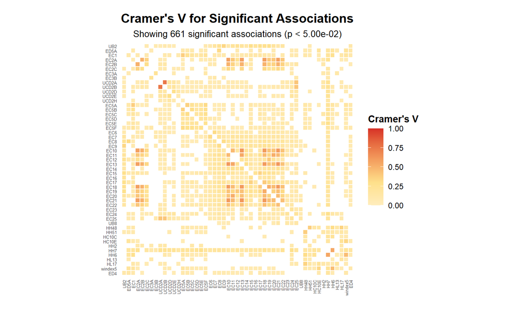

```r
# Create heatmap
plot <- plot_cramers_heatmap(results)
print(plot)
```

```r
# View top associations
top_20 <- get_top_associations(results, n = 20)
print(top_20)
```

```
#>       Var1  Var2  CramersV ChiSquare        PValue
#> 45   UCD2A UCD2B 0.7507201  3246.225  0.000000e+00
#> 588   EC13  EC21 0.6210251  3332.207  0.000000e+00
#> 349   EC10  EC13 0.6133845  3250.719  0.000000e+00
#> 593   EC18  EC21 0.6048174  3160.547  0.000000e+00
#> 492   EC13  EC18 0.6043857  3156.037  0.000000e+00
#> 585   EC10  EC21 0.6005393  3115.994  0.000000e+00
#> 489   EC10  EC18 0.5942122  3050.681  0.000000e+00
#> 469   EC2A  EC18 0.5778592  2885.079  0.000000e+00
#> 257   EC2A  EC10 0.5775260  2881.753  0.000000e+00
#> 565   EC2A  EC21 0.5775212  2881.706  0.000000e+00
#> 329   EC2A  EC13 0.5774484  2880.979  0.000000e+00
#> 1081   HH7   HH6 0.5521612   878.060 5.305723e-174
#> 350   EC11  EC13 0.5479284  2593.948  0.000000e+00
#> 553   EC11  EC20 0.5212754  2347.731  0.000000e+00
#> 528   EC18  EC19 0.5209768  2345.041  0.000000e+00
#> 10    EC2A  EC2B 0.5067409  1479.090 1.810713e-316
#> 258   EC2B  EC10 0.5048221  1467.909 4.775285e-314
#> 566   EC2B  EC21 0.5045787  1466.494 9.672213e-314
#> 330   EC2B  EC13 0.5019963  1451.522 1.689652e-310
#> 470   EC2B  EC18 0.5005916  1443.409 9.650179e-309
```

- EC2[A-C] (presence of playthings) seem to be associated with the variables corresponding to the components of Early Childhood Development Index 2030 (ECDI2030, variables EC6-EC25).
- As expected, items measuring one phenomena are associated with each other: we can see clear colored clusters for Child Discipline UCD2[A-H] group of variables, for playthings materials EC2[A-C], EC5[A-F] - early stimulation and responsive care set, and the most clear one for the EC6-EC25, i.e. ECDI2030. All of these groups will be consolidated later, so these associations should not be problematic.
- There is a weak association between HH7 - region of the household, and the majority of variables, which is nicely justifying our usage of multilevel modeling.
- HH48 (number of household members) seems to be associated with other household characteristics like number of children under 5 (HH51), wealth (windex5), having vehicles like a motorcycle or a car, and mother/father of the child living in the household (HL13/HL17, respectively), and also with early stimulation and responsive care (EC5[A-F]).
- **The most concerning finding: few (just 9, without any household-related features) pairwise associations between target variable “UB8” and the rest of predictors**. If this will also be the reflected in the multilevel modelling results, we will consider selecting out the component items and using them instead of composite scores (e.g. separate early childhood development items instead of ECDI2030).

### Regional level (n=20)

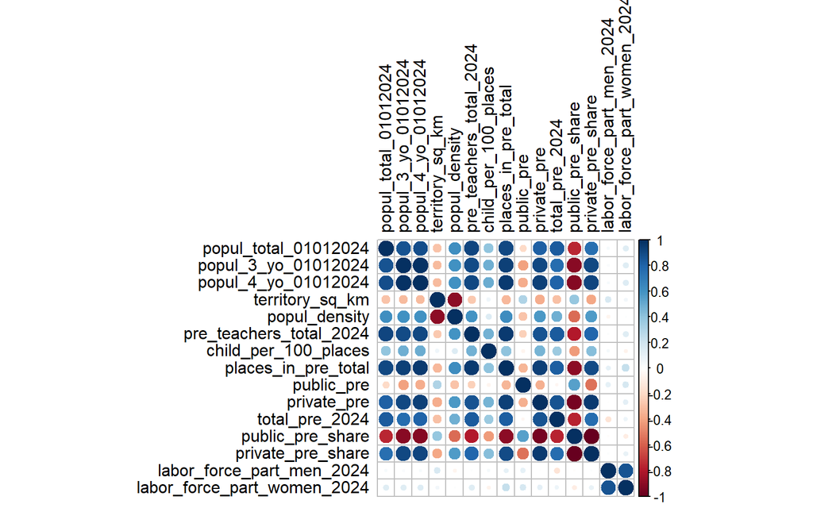

```r
numeric_vars <- region_kz[sapply(region_kz, is.numeric)]
region_kz.cor <- cor(numeric_vars, method = "spearman")
corrplot(region_kz.cor, tl.col="black")
```

Here, we can observe the following tendencies:

- Labor force participation by both men and women is very weakly correlated with any other variables.
- The total population of the region seems to be highly correlated with most preschool education-related variables, whereas population density is only moderately correlated with them.

# 3. Further concerns to discuss

1. It needs to be decided, which variables would be the most adequate to select for the regional level. By now, there are too many, and some of them are clearly redundant. Also, their rescaling is to be discussed.
2. We are unsure whether chosen recoding and missing values imputation strategies are adequate.
3. The is a proposition to handle the imbalance in the target variable in Tajikistan through adjusting class weights.